# Modelos Temporales — Desapariciones en CDMX

## Efecto dinámico de homicidios — β₁ₜ

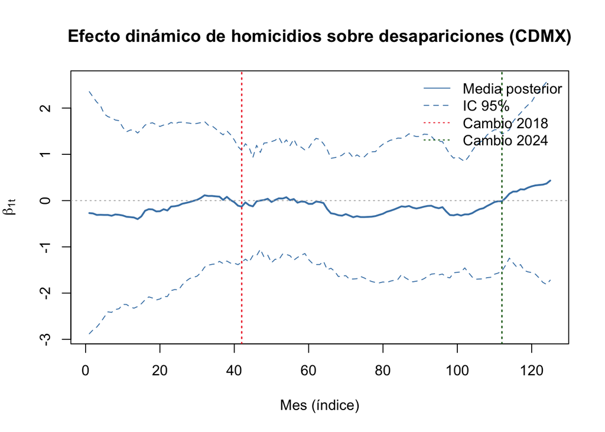

```r
# Gráfica principal — evolución del efecto de homicidios
# Análoga a out.beta[seq(1,312,by=3),1] del Ej. 10 del Prof.
out4.beta1 <- out4.sum[grep("^beta1", rownames(out4.sum)), ]
ymin <- min(out4.beta1[, c(1, 3, 7)])
ymax <- max(out4.beta1[, c(1, 3, 7)])
par(mfrow = c(1, 1))
plot(t_dlm, out4.beta1[, 1],
     type = "l", lwd = 2, col = "steelblue",
     ylim = c(ymin, ymax),
     xlab = "Mes (índice)",
     ylab = expression(beta[1][t]),
     main = "Efecto dinámico de homicidios sobre desapariciones (CDMX)")
lines(t_dlm, out4.beta1[, 3], lty = 2, col = "steelblue")
lines(t_dlm, out4.beta1[, 7], lty = 2, col = "steelblue")
abline(h = 0, col = "grey70", lty = 3)
abline(v = which(agg$post_2018 == 1)[1],
       col = "firebrick2", lty = 3, lwd = 1.5)
abline(v = which(agg$post_2024 == 1)[1],
       col = "darkgreen", lty = 3, lwd = 1.5)
legend("topright",
       legend = c("Media posterior", "IC 95%",
                  "Cambio 2018", "Cambio 2024"),
       col = c("steelblue", "steelblue", "firebrick2", "darkgreen"),
       lty = c(1, 2, 3, 3), bty = "n")
```

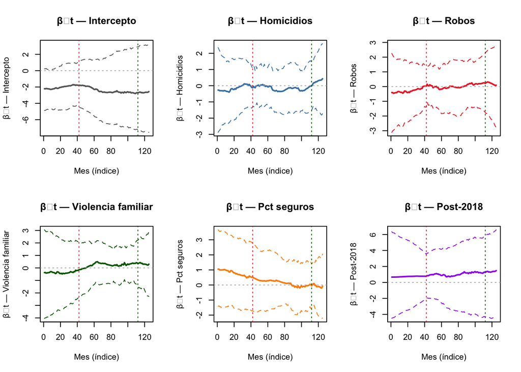

```r
# Los 6 betas juntos — análogo a los plots del Ej. 10 del Prof.
beta_names <- c("beta0", "beta1", "beta2",
                "beta3", "beta4", "beta5")
titulos    <- c("β₀t — Intercepto",
                "β₁t — Homicidios",
                "β₂t — Robos",
                "β₃t — Violencia familiar",
                "β₄t — Pct seguros",
                "β₅t — Post-2018")
colores    <- c("grey40", "steelblue", "firebrick2",
                "darkgreen", "darkorange", "purple")

par(mfrow = c(2, 3))
for (j in seq_along(beta_names)) {
  out.bj <- out4.sum[grep(paste0("^", beta_names[j]),
                          rownames(out4.sum)), ]
  ymin <- min(out.bj[, c(1, 3, 7)])
  ymax <- max(out.bj[, c(1, 3, 7)])
  plot(t_dlm, out.bj[, 1],
       type = "l", lwd = 2, col = colores[j],
       ylim = c(ymin, ymax),
       xlab = "Mes (índice)", ylab = titulos[j],
       main = titulos[j])
  lines(t_dlm, out.bj[, 3], lty = 2, col = colores[j])
  lines(t_dlm, out.bj[, 7], lty = 2, col = colores[j])
  abline(h = 0, col = "grey70", lty = 3)
  abline(v = which(agg$post_2018 == 1)[1],
         col = "firebrick2", lty = 3)
  abline(v = which(agg$post_2024 == 1)[1],
         col = "darkgreen", lty = 3)
}
```

```r
par(mfrow = c(1, 1))
```

β₁t — Homicidios Oscila alrededor de 0, IC cruza cero constantemente. Sin efecto claro — confirma lo que vimos en M1 y M2.

β₄t — Pct seguros Positivo al inicio, decrece hacia cero. IC muy amplio. Poca señal.

β₅t — Post-2018 Oscila alrededor de 1, IC muy amplio que cruza cero. No hay salto claro en la línea roja.

```r
# Modelo 4 — resumen de las sigmas (varianza del sistema)
# que indican cuánto evolucionó cada coeficiente
print("=== MODELO 4 — varianza del sistema ===")
```

```
## [1] "=== MODELO 4 — varianza del sistema ==="
```

```r
print(out4.sum[grep("^sig", rownames(out4.sum)), c(1, 3, 7)])
```

```
##             mean      2.5%     97.5%
## sig.w0 0.3570229 0.2736707 0.4645748
## sig.w1 0.3665571 0.2773623 0.4828762
## sig.w2 0.3723866 0.2798990 0.4938789
## sig.w3 0.3662533 0.2769158 0.4824201
## sig.w4 0.3647154 0.2760287 0.4797177
## sig.w5 0.3826698 0.2867377 0.5121185
```

Esto significa que todos los coeficientes evolucionan con la misma intensidad — ninguno es particularmente más dinámico que otro. El IC de los betas al inicio y al final es enormemente amplio, confirmando lo que vimos en la gráfica: el modelo dinamico tiene mucha incertidumbre mes a mes.

```r
# =================================================================== #
# COMPARACIÓN DIC — todos los modelos
# =================================================================== #
print("=== COMPARACIÓN DIC — TODOS LOS MODELOS ===")
```

```
## [1] "=== COMPARACIÓN DIC — TODOS LOS MODELOS ==="
```

```r
print(data.frame(
  Modelo = c("Mod1 — Poisson Breakpoint (baseline)",
             "Mod2 — Binomial Negativa + Covariables",
             "Mod3 — Poisson Efectos Aleatorios",
             "Mod4 — DLM Coeficientes Dinámicos"),
  DIC    = c(round(out1.dic, 2),
             round(out2.dic, 2),
             round(out3.dic, 2),
             round(out4.dic, 2))
))
```

```
##                                   Modelo     DIC
## 1   Mod1 — Poisson Breakpoint (baseline)  707.80
## 2 Mod2 — Binomial Negativa + Covariables  680.82
## 3      Mod3 — Poisson Efectos Aleatorios 2975.52
## 4      Mod4 — DLM Coeficientes Dinámicos  706.59
```

```r
# ==================================
# PREGUNTAS
# ==================================
```